# SVD

## 目的 : LSA(Trancated SVD)を実行して低次元に圧縮し可視化する。また、前処理(標準化、無相関化、白色化)を行い、それぞれの効果を確認する。

### STEP1 : データを読み込んでどのようなデータか確認する。

- 今回はsklearnのirisデータを使う。

```python
import numpy as np
import pandas as pd
from sklearn import datasets
import matplotlib.pyplot as plt
from mpl_toolkits.mplot3d import Axes3D

# irisデータをdataframeに格納
iris = datasets.load_iris()
df_iris = pd.DataFrame(iris.data, columns=iris.feature_names)

# target列(Calss label=今回は品種名)を追加
df_iris["target"] = iris.target_names[iris.target]

# 表示
df_iris.head()
```

|  | sepal length (cm) | sepal width (cm) | petal length (cm) | petal width (cm) | target |
| --- | --- | --- | --- | --- | --- |
| 0 | 5.1 | 3.5 | 1.4 | 0.2 | setosa |
| 1 | 4.9 | 3.0 | 1.4 | 0.2 | setosa |
| 2 | 4.7 | 3.2 | 1.3 | 0.2 | setosa |
| 3 | 4.6 | 3.1 | 1.5 | 0.2 | setosa |
| 4 | 5.0 | 3.6 | 1.4 | 0.2 | setosa |

```python
# 形状の確認
df_iris.shape
```

```
(150, 5)
```

```python
# Class labelの確認
df_iris["target"].value_counts()
```

```
virginica     50
versicolor    50
setosa        50
Name: target, dtype: int64
```

```python
# 欠損値などの確認(今回はirisデータセットを使うため問題なし)
print(df_iris.info())
```

```
<class 'pandas.core.frame.DataFrame'>
RangeIndex: 150 entries, 0 to 149
Data columns (total 5 columns):
 #   Column             Non-Null Count  Dtype
---  ------             --------------  -----
 0   sepal length (cm)  150 non-null    float64
 1   sepal width (cm)   150 non-null    float64
 2   petal length (cm)  150 non-null    float64
 3   petal width (cm)   150 non-null    float64
 4   target             150 non-null    object
dtypes: float64(4), object(1)
memory usage: 6.0+ KB
None
```

```python
# 各特徴量の統計量を表示
df_iris.describe()
```

|  | sepal length (cm) | sepal width (cm) | petal length (cm) | petal width (cm) |
| --- | --- | --- | --- | --- |
| count | 150.000000 | 150.000000 | 150.000000 | 150.000000 |
| mean | 5.843333 | 3.057333 | 3.758000 | 1.199333 |
| std | 0.828066 | 0.435866 | 1.765298 | 0.762238 |
| min | 4.300000 | 2.000000 | 1.000000 | 0.100000 |
| 25% | 5.100000 | 2.800000 | 1.600000 | 0.300000 |
| 50% | 5.800000 | 3.000000 | 4.350000 | 1.300000 |
| 75% | 6.400000 | 3.300000 | 5.100000 | 1.800000 |
| max | 7.900000 | 4.400000 | 6.900000 | 2.500000 |

#### ここまででわかったこと

- サンプル数(=群数=クラス数)は3
- Class labelは品種名(virginica, versicolor, setosa)
- サンプルサイズは50(合計150)
- 特徴量は4種類(sepal=がくの長さと幅、petal=花びらの長さと幅)
- 特徴量の型は全て統一されている(float64)
- 特徴量の単位は全て統一されている(cm)
- 各特徴量のスケールはかなり異なり、正規化や標準化などの処理は行われていない
- 欠損値はなし

```python
# sklearnのデータセットはDESCRアトリビュートに各特徴量の説明や統計量、欠損値の有無などが記入されているので、上記と矛盾していないことを確認する。
print(iris.DESCR)
```

```
.. _iris_dataset:

Iris plants dataset
--------------------

**Data Set Characteristics:**

    :Number of Instances: 150 (50 in each of three classes)
    :Number of Attributes: 4 numeric, predictive attributes and the class
    :Attribute Information:
        - sepal length in cm
        - sepal width in cm
        - petal length in cm
        - petal width in cm
        - class:
                - Iris-Setosa
                - Iris-Versicolour
                - Iris-Virginica

    :Summary Statistics:

    ============== ==== ==== ======= ===== ====================
                    Min  Max   Mean    SD   Class Correlation
    ============== ==== ==== ======= ===== ====================
    sepal length:   4.3  7.9   5.84   0.83    0.7826
    sepal width:    2.0  4.4   3.05   0.43   -0.4194
    petal length:   1.0  6.9   3.76   1.76    0.9490  (high!)
    petal width:    0.1  2.5   1.20   0.76    0.9565  (high!)
    ============== ==== ==== ======= ===== ====================

    :Missing Attribute Values: None
    :Class Distribution: 33.3% for each of 3 classes.
    :Creator: R.A. Fisher
    :Donor: Michael Marshall (MARSHALL%PLU@io.arc.nasa.gov)
    :Date: July, 1988

The famous Iris database, first used by Sir R.A. Fisher. The dataset is taken
from Fisher's paper. Note that it's the same as in R, but not as in the UCI
Machine Learning Repository, which has two wrong data points.

```

[output cut: 8 more lines]

```

   - Fisher, R.A. "The use of multiple measurements in taxonomic problems"
     Annual Eugenics, 7, Part II, 179-188 (1936); also in "Contributions to
     Mathematical Statistics" (John Wiley, NY, 1950).
   - Duda, R.O., & Hart, P.E. (1973) Pattern Classification and Scene Analysis.
     (Q327.D83) John Wiley & Sons.  ISBN 0-471-22361-1.  See page 218.
   - Dasarathy, B.V. (1980) "Nosing Around the Neighborhood: A New System
     Structure and Classification Rule for Recognition in Partially Exposed
     Environments".  IEEE Transactions on Pattern Analysis and Machine
     Intelligence, Vol. PAMI-2, No. 1, 67-71.
   - Gates, G.W. (1972) "The Reduced Nearest Neighbor Rule".  IEEE Transactions
     on Information Theory, May 1972, 431-433.
   - See also: 1988 MLC Proceedings, 54-64.  Cheeseman et al"s AUTOCLASS II
     conceptual clustering system finds 3 classes in the data.
   - Many, many more ...
```

### STEP2 : 可視化できるように次元削減を行う(各特徴量ごとの前処理はまだ行わない)

- 1グラフで可視化したかったら特徴量を3つ以下にすればOK。(Class labelは色やマーカーの形状で分類できるため。)
- 次元削減することで、可視化できるようになるだけでなく、計算量削減・メモリ削減の効果もある。
- 次元削減の手法は大きく分けて「特徴選択」と「特徴抽出」がある。
- 特徴選択は、既存の特徴量のうち有効ではない特徴量を捨てるもの。
  - 一例として、相関や相互情報量などを元にしきい値を設けてフィルタリングする手法(フィルタ法)がある。
- 特徴抽出は、効率的な新しい特徴量(の列)を作るもの。
  - 「One-hotベクトルで表される文章」などのスパースな行列では、特徴選択の効果が薄いので特徴抽出の方が有効。
  - 様々な行列を圧縮できる手法として有名な手法を挙げる。
    - PCA(Principal Component Analysis、主成分分析) : データの分散が最大になるような主成分の基底を、第一主成分から順に定める。それぞれの基底に線形独立。分散共分散行列を対角化する。
    - Truncated SVD : SVDを行った後、特異値の小さい特徴量を切り捨てる(truncateする)。**←今回はこれをやります。SVDの詳細については別記します。**
    - LDA(Linear Discriminant Analysis、線形判別分析) : まだ理解が十分ではないのでわかったら後で追記します。
    - ICA(independent component analysis、独立成分分析) : SVDを行った後、直交行列Uが統計的に独立であると仮定するらしいですがまだ理解が十分ではないのでわかったら後で追記します。
      - 余談ですが、「LDA」がLatent Dirichlet Allocation(潜在的ディリクレ配分法)を指すことが有ります(トピックモデルの文脈)
      - 文献を探す際などは、混同して混乱しないよう注意する必要が有ります(混乱しました)
- ドメイン固有の特徴抽出手法で有名なものを挙げる。
  - 画像 : SIFT(拡大縮小ノイズに強い。特徴点(Keypoint)を抽出して特徴量=記述子(descriptor、SIFTでは勾配を用いる)を割り当てる)、HOG(点ではなく領域に特徴量(勾配)を割り当てる)
  - 文書 : LSA(Latent Semantic Analysisの略。潜在意味解析。やっていることはTruncated SVDと同じ)、TF-IDF({文書集合, 文書, 単語}の3つ組に対して重要度を表すスカラを与える。1文書内における頻度と文書集合内における出現割合を用いる。)

```python
# SVDにはnumpyのlinalg.svdメソッドを使う
U, D, V = np.linalg.svd(iris.data)
```

```python
U # 150x150の新特徴量。直交行列
```

```
array([[-0.06161685,  0.12961144,  0.0021386 , ..., -0.09343429,
        -0.09573864, -0.08085465],
       [-0.05807094,  0.11101978,  0.07067239, ...,  0.03690405,
        -0.03153954,  0.01309526],
       [-0.05676305,  0.11796647,  0.00434255, ...,  0.03066199,
         0.19531473,  0.13569909],
       ...,
       [-0.0940593 , -0.0498297 , -0.04144001, ...,  0.98181631,
        -0.02194514, -0.00894446],
       [-0.09488961, -0.05610123, -0.21297821, ..., -0.02155617,
         0.94178018, -0.02971961],
       [-0.08847836, -0.0515697 , -0.09575285, ..., -0.0086052 ,
        -0.03021088,  0.9736599 ]])
```

```python
D # 特異値(もともとの特徴量が4列なので、4個の特異値が出る)
```

```
array([95.95991387, 17.76103366,  3.46093093,  1.88482631])
```

```python
V # 計算合わせの直交行列
```

```
array([[-0.75110816, -0.38008617, -0.51300886, -0.16790754],
       [ 0.2841749 ,  0.5467445 , -0.70866455, -0.34367081],
       [ 0.50215472, -0.67524332, -0.05916621, -0.53701625],
       [ 0.32081425, -0.31725607, -0.48074507,  0.75187165]])
```

### STEP3 : 可視化する

- 3次元、2次元、1次元それぞれ行う。
- 1次元の場合は、第一の(最大の)特異値を用いた場合と、第二の特異値を用いた場合、両方確かめる。

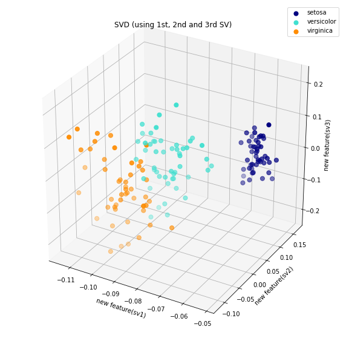

```python
# 3次元(新しい特徴量のうち、最初の3列を取り出す)

df_iris_svd_3d = pd.DataFrame(U[:,:3], columns=["sv1", "sv2", "sv3"])
df_iris_svd_3d ["target"] = iris.target_names[iris.target]

# plot
fig = plt.figure(figsize=(10, 10))
ax = fig.add_subplot(111 , projection="3d")

colors = ["navy", "turquoise", "darkorange"]

for color, target, label in zip(colors, target_names, target_names):

    sv1 = df_iris_svd_3d[df_iris_svd_3d["target"]==target].loc[:, "sv1"]
    sv2 = df_iris_svd_3d[df_iris_svd_3d["target"]==target].loc[:, "sv2"]
    sv3 = df_iris_svd_3d[df_iris_svd_3d["target"]==target].loc[:, "sv3"]
    sc = ax.scatter(sv1, sv2, zs=sv3, zdir='z', s=50, vmin=0, vmax=1, c=color, label=label)

plt.legend(loc="best", shadow=False, scatterpoints=1)

plt.xlabel("new feature(sv1)")
plt.ylabel("new feature(sv2)")
ax.set_zlabel("new feature(sv3)")

plt.title("SVD (using 1st, 2nd and 3rd SV)")

plt.grid(True)
plt.show()
```

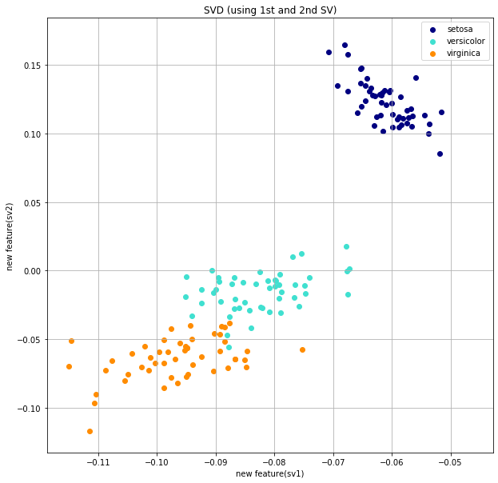

```python
# 2次元(新しい特徴量のうち、最初の2列を取り出す)

df_iris_svd_2d = pd.DataFrame(U[:,:2], columns=["sv1", "sv2"])
df_iris_svd_2d ["target"] = iris.target_names[iris.target]

# plot
plt.figure(figsize=(10,10))

colors = ['navy', 'turquoise', 'darkorange']

for color, target, label in zip(colors, target_names, target_names):

    sv1 = df_iris_svd_2d[df_iris_svd_2d["target"]==target].loc[:, "sv1"]
    sv2 = df_iris_svd_2d[df_iris_svd_2d["target"]==target].loc[:, "sv2"]
    plt.scatter(sv1,sv2, color=color,label=label)

plt.legend(loc='best', shadow=False, scatterpoints=1)
plt.xlabel("new feature(sv1)")
plt.ylabel("new feature(sv2)")
plt.title("SVD (using 1st and 2nd SV)")

plt.grid(True)
plt.show()
```

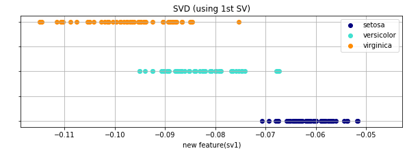

```python
# 新しい特徴量のうち、最初の1列を取り出す

df_iris_svd_1d_1 = pd.DataFrame(U[:, 0], columns=["sv1"])
df_iris_svd_1d_1["target"] = iris.target_names[iris.target]

# plot
plt.figure(figsize=(10, 3))

colors = ['navy', 'turquoise', 'darkorange']
y_axis = np.arange(3)

for y, color, target, label in zip(y_axis, colors, target_names, target_names):

    sv1 = df_iris_svd_1d_1[df_iris_svd_1d_1["target"]==target].loc[:, "sv1"]
    y = np.ones(len(sv1)) * y

    plt.scatter(sv1, y, color=color,label=label)

plt.legend(loc='best', shadow=False, scatterpoints=1)
plt.xlabel("new feature(sv1)")
plt.yticks(color="None")
plt.title("SVD (using 1st SV)")
plt.grid(True)
plt.show()
```

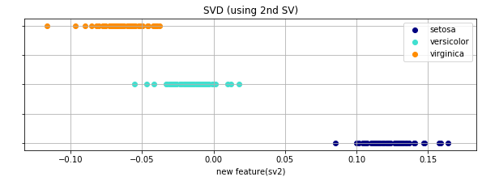

```python
# 新しい特徴量のうち、2列目を取り出す

df_iris_svd_1d_2 = pd.DataFrame(U[:, 1], columns=["sv1"])
df_iris_svd_1d_2["target"] = iris.target_names[iris.target]

# plot

plt.figure(figsize=(10, 3))

colors = ['navy', 'turquoise', 'darkorange']
y_axis = np.arange(3)

for y, color, target, label in zip(y_axis, colors, target_names, target_names):

    sv1 = df_iris_svd_1[df_iris_svd_1["target"]==target].loc[:, "sv1"]
    y = np.ones(len(sv1)) * y

    plt.scatter(sv1, y, color=color,label=label)

plt.legend(loc='best', shadow=False, scatterpoints=1)
plt.xlabel("new feature(sv2)")
plt.yticks(color="None")
plt.title("SVD (using 2nd SV)")
plt.grid(True)
plt.show()
```

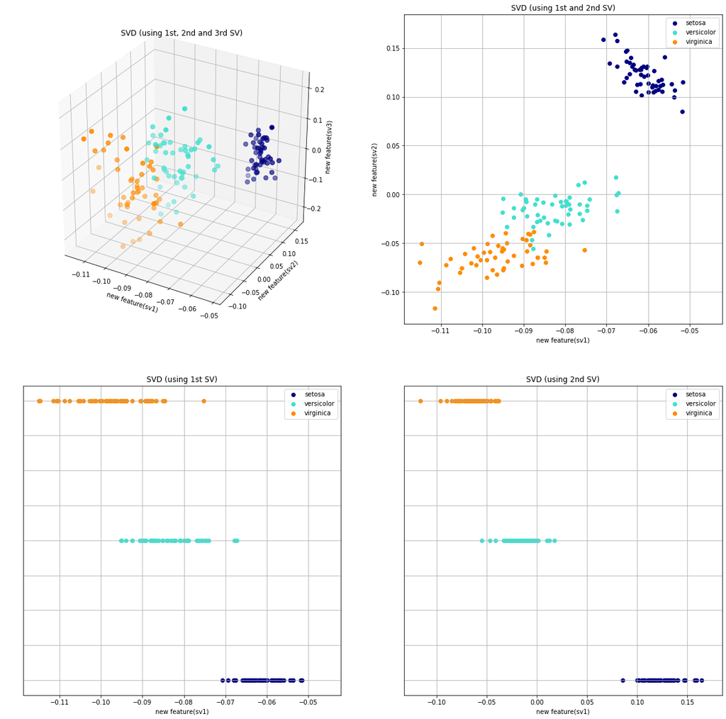

```python
# 4つ並べて書いてみる
fig = plt.figure(figsize=(20, 20))

#-----------------------------------------------------------

# 3d
ax_3d = fig.add_subplot(221 , projection="3d")

colors = ["navy", "turquoise", "darkorange"]

for color, target, label in zip(colors, target_names, target_names):

    sv1 = df_iris_svd_3d[df_iris_svd_3d["target"]==target].loc[:, "sv1"]
    sv2 = df_iris_svd_3d[df_iris_svd_3d["target"]==target].loc[:, "sv2"]
    sv3 = df_iris_svd_3d[df_iris_svd_3d["target"]==target].loc[:, "sv3"]
    sc = ax_3d.scatter(sv1, sv2, zs=sv3, zdir='z', s=50, vmin=0, vmax=1, c=color, label=label)

#ax_3d.legend(loc="best", shadow=False, scatterpoints=1)

ax_3d.set_xlabel("new feature(sv1)")
ax_3d.set_ylabel("new feature(sv2)")
ax_3d.set_zlabel("new feature(sv3)")
ax_3d.set_title("SVD (using 1st, 2nd and 3rd SV)")
ax_3d.grid(True)

#-----------------------------------------------------------

#2d
ax_2d = fig.add_subplot(222)

colors = ['navy', 'turquoise', 'darkorange']

for color, target, label in zip(colors, target_names, target_names):

    sv1 = df_iris_svd_2d[df_iris_svd_2d["target"]==target].loc[:, "sv1"]
    sv2 = df_iris_svd_2d[df_iris_svd_2d["target"]==target].loc[:, "sv2"]
    plt.scatter(sv1,sv2, color=color,label=label)

ax_2d.legend(loc='best', shadow=False, scatterpoints=1)
ax_2d.set_xlabel("new feature(sv1)")
ax_2d.set_ylabel("new feature(sv2)")
ax_2d.set_title("SVD (using 1st and 2nd SV)")
ax_2d.grid(True)

#-----------------------------------------------------------

#1d_1
ax_1d_1 = fig.add_subplot(223)
colors = ['navy', 'turquoise', 'darkorange']
y_axis = np.arange(3)

for y, color, target, label in zip(y_axis, colors, target_names, target_names):

    sv1 = df_iris_svd_1d_1[df_iris_svd_1d_1["target"]==target].loc[:, "sv1"]
    y = np.ones(len(sv1)) * y

    ax_1d_1.scatter(sv1, y, color=color,label=label)

ax_1d_1.legend(loc='best', shadow=False, scatterpoints=1)
ax_1d_1.set_xlabel("new feature(sv1)")
ax_1d_1.tick_params(axis="y", colors="None")
ax_1d_1.set_title("SVD (using 1st SV)")
ax_1d_1.grid(True)

#-----------------------------------------------------------

#1d_2
ax_1d_2 = fig.add_subplot(224)
colors = ['navy', 'turquoise', 'darkorange']
y_axis = np.arange(3)

for y, color, target, label in zip(y_axis, colors, target_names, target_names):

    sv1 = df_iris_svd_1d_2[df_iris_svd_1d_1["target"]==target].loc[:, "sv1"]
    y = np.ones(len(sv1)) * y

    ax_1d_2.scatter(sv1, y, color=color,label=label)

ax_1d_2.legend(loc='best', shadow=False, scatterpoints=1)
ax_1d_2.set_xlabel("new feature(sv1)")
ax_1d_2.tick_params(axis="y", colors="None")
ax_1d_2.set_title("SVD (using 2nd SV)")
ax_1d_2.grid(True)

#-----------------------------------------------------------
plt.grid(True)
plt.show()
```

#### ここまでで思ったこと

- 3d, 2d, 1dの2種, どれも分離がわかりやすい
- しかし、第一の特異値と用いた図と第二の特異値を用いた図を比較すると、第二の特異値を用いたほうがよく分離しているように見える。(原因はまだわからない)
- データのスケールが違うことではないかと考え、前処理でデータのスケールをそろえてから再度プロットしてみる。

### STEP4 : 前処理して可視化する(1) : 正規化(min-maxスケーリング)

- テーブルデータの前処理の主な手法を挙げる。(大体sklearn.preprocessingに入ってるので便利)
  - 正規化(min-maxスケーリング) : [0, 1]や[-1, 1]といった区間内に変換する
  - 標準化 : 平均0, 分散1に変換する
  - 無相関化 : データ間の相関を０にする
  - 白色化 : データ間の相関を0にした後、平均0, 分散1に変換する
- まずは正規化(min-maxスケーリング)を適用する。
- [0, 1]に変換する。

```python
import sklearn.preprocessing

# sample
sklearn.preprocessing.minmax_scale([-1, 0, 1, 2, 3])
```

```
array([0.  , 0.25, 0.5 , 0.75, 1.  ])
```

```python
# scale
df_minmax = df_iris
for feature_name in iris.feature_names:
    df_minmax[feature_name] = sklearn.preprocessing.minmax_scale(df_minmax[feature_name])

df_minmax.describe()
```

|  | sepal length (cm) | sepal width (cm) | petal length (cm) | petal width (cm) |
| --- | --- | --- | --- | --- |
| count | 150.000000 | 150.000000 | 150.000000 | 150.000000 |
| mean | 0.428704 | 0.440556 | 0.467458 | 0.458056 |
| std | 0.230018 | 0.181611 | 0.299203 | 0.317599 |
| min | 0.000000 | 0.000000 | 0.000000 | 0.000000 |
| 25% | 0.222222 | 0.333333 | 0.101695 | 0.083333 |
| 50% | 0.416667 | 0.416667 | 0.567797 | 0.500000 |
| 75% | 0.583333 | 0.541667 | 0.694915 | 0.708333 |
| max | 1.000000 | 1.000000 | 1.000000 | 1.000000 |

```python
# SVD
U_minmax, D_minmax, V_minmax = np.linalg.svd(df_minmax[iris.feature_names])
df_minmax_svd = pd.DataFrame(U_minmax[:,:3], columns=["sv1", "sv2", "sv3"])
df_minmax_svd["target"] = iris.target_names[iris.target]
```

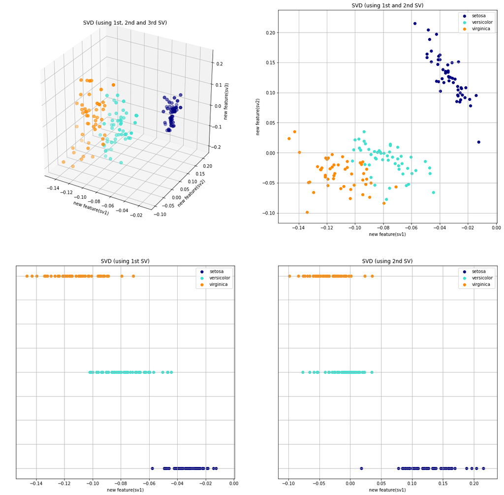

```python
# 4つ並べて書いてみる
fig = plt.figure(figsize=(20, 20))

#-----------------------------------------------------------

# 3d
ax_3d = fig.add_subplot(221 , projection="3d")

colors = ["navy", "turquoise", "darkorange"]

for color, target, label in zip(colors, target_names, target_names):

    sv1 = df_minmax_svd[df_minmax_svd["target"]==target].loc[:, "sv1"]
    sv2 = df_minmax_svd[df_minmax_svd["target"]==target].loc[:, "sv2"]
    sv3 = df_minmax_svd[df_minmax_svd["target"]==target].loc[:, "sv3"]
    sc = ax_3d.scatter(sv1, sv2, zs=sv3, zdir='z', s=50, vmin=0, vmax=1, c=color, label=label)

#ax_3d.legend(loc="best", shadow=False, scatterpoints=1)

ax_3d.set_xlabel("new feature(sv1)")
ax_3d.set_ylabel("new feature(sv2)")
ax_3d.set_zlabel("new feature(sv3)")
ax_3d.set_title("SVD (using 1st, 2nd and 3rd SV)")
ax_3d.grid(True)

#-----------------------------------------------------------

#2d
ax_2d = fig.add_subplot(222)

colors = ['navy', 'turquoise', 'darkorange']

for color, target, label in zip(colors, target_names, target_names):

    sv1 = df_minmax_svd[df_minmax_svd["target"]==target].loc[:, "sv1"]
    sv2 = df_minmax_svd[df_minmax_svd["target"]==target].loc[:, "sv2"]
    plt.scatter(sv1,sv2, color=color,label=label)

ax_2d.legend(loc='best', shadow=False, scatterpoints=1)
ax_2d.set_xlabel("new feature(sv1)")
ax_2d.set_ylabel("new feature(sv2)")
ax_2d.set_title("SVD (using 1st and 2nd SV)")
ax_2d.grid(True)

#-----------------------------------------------------------

#1d_1
ax_1d_1 = fig.add_subplot(223)
colors = ['navy', 'turquoise', 'darkorange']
y_axis = np.arange(3)

for y, color, target, label in zip(y_axis, colors, target_names, target_names):

    sv1 = df_minmax_svd[df_minmax_svd["target"]==target].loc[:, "sv1"]
    y = np.ones(len(sv1)) * y

    ax_1d_1.scatter(sv1, y, color=color,label=label)

ax_1d_1.legend(loc='best', shadow=False, scatterpoints=1)
ax_1d_1.set_xlabel("new feature(sv1)")
ax_1d_1.tick_params(axis="y", colors="None")
ax_1d_1.set_title("SVD (using 1st SV)")
ax_1d_1.grid(True)

#-----------------------------------------------------------

#1d_2
ax_1d_2 = fig.add_subplot(224)
colors = ['navy', 'turquoise', 'darkorange']
y_axis = np.arange(3)

for y, color, target, label in zip(y_axis, colors, target_names, target_names):

    sv1 = df_minmax_svd[df_minmax_svd["target"]==target].loc[:, "sv2"]
    y = np.ones(len(sv1)) * y

    ax_1d_2.scatter(sv1, y, color=color,label=label)

ax_1d_2.legend(loc='best', shadow=False, scatterpoints=1)
ax_1d_2.set_xlabel("new feature(sv1)")
ax_1d_2.tick_params(axis="y", colors="None")
ax_1d_2.set_title("SVD (using 2nd SV)")
ax_1d_2.grid(True)

#-----------------------------------------------------------
plt.grid(True)
plt.show()
```

#### ここまでで思ったこと

- さっき(前処理なし)よりも、2nd SVを用いた際と比較しすると、1st SVを用いた際の分離の方が良くなっている。
- やはりスケーリングは大事
- パンゼミのOhnoさんに以下のような意見を頂きました、ありがとうございます！
  - 「特異値分解によるデータ行列の低ランク近似は、近似後の行列とのフロベニウス距離を最小にするようなものになります」
  - 「なので特徴量のスケールがあってないとスケールの大きな特徴量の誤差に引きずられて少し精度の悪い特徴量が出てきちゃうのかな」

### STEP5 : 前処理して可視化する(2) : 標準化

- テーブルデータの前処理の主な手法を挙げる。(大体sklearn.preprocessingに入ってるので便利)
  - 正規化(min-maxスケーリング) : [0, 1]や[-1, 1]といった区間内に変換する
  - 標準化 : 平均0, 分散1に変換する
  - 無相関化 : データ間の相関を０にする
  - 白色化 : データ間の相関を0にした後、平均0, 分散1に変換する
- 続いて標準化を試す。

```python
import sklearn.preprocessing

# sample
sample = sklearn.preprocessing.scale([-1, 0, 1, 2, 3])

print("平均", np.mean(sample))
print("分散", np.var(sample))
```

```
平均 0.0
分散 0.9999999999999998
```

```python
# scale
df_standardize = df_iris
for feature_name in iris.feature_names:
    df_standardize[feature_name] = sklearn.preprocessing.scale(df_standardize[feature_name])

df_standardize.describe()
```

|  | sepal length (cm) | sepal width (cm) | petal length (cm) | petal width (cm) |
| --- | --- | --- | --- | --- |
| count | 1.500000e+02 | 150.000000 | 1.500000e+02 | 1.500000e+02 |
| mean | 1.421085e-16 | 0.000000 | 1.894781e-16 | -9.473903e-17 |
| std | 1.003350e+00 | 1.003350 | 1.003350e+00 | 1.003350e+00 |
| min | -1.870024e+00 | -2.433947 | -1.567576e+00 | -1.447076e+00 |
| 25% | -9.006812e-01 | -0.592373 | -1.226552e+00 | -1.183812e+00 |
| 50% | -5.250608e-02 | -0.131979 | 3.364776e-01 | 1.325097e-01 |
| 75% | 6.745011e-01 | 0.558611 | 7.627583e-01 | 7.906707e-01 |
| max | 2.492019e+00 | 3.090775 | 1.785832e+00 | 1.712096e+00 |

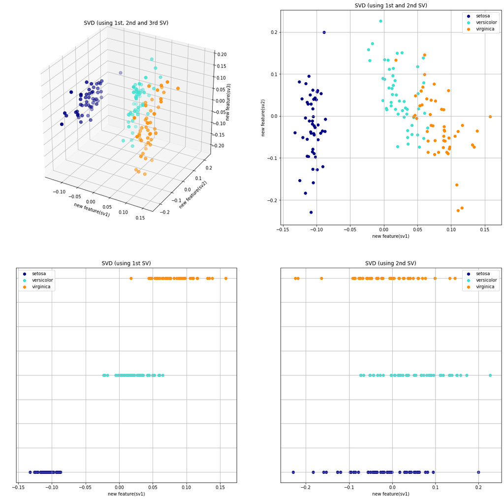

```python
# SVD
U_standardize, D_standardize, V_standardize = np.linalg.svd(df_minmax[iris.feature_names])
df_standardize_svd = pd.DataFrame(U_standardize[:,:3], columns=["sv1", "sv2", "sv3"])
df_standardize_svd["target"] = iris.target_names[iris.target]

# 4つ並べて書いてみる
fig = plt.figure(figsize=(20, 20))

#-----------------------------------------------------------

# 3d
ax_3d = fig.add_subplot(221 , projection="3d")

colors = ["navy", "turquoise", "darkorange"]

for color, target, label in zip(colors, target_names, target_names):

    sv1 = df_standardize_svd[df_standardize_svd["target"]==target].loc[:, "sv1"]
    sv2 = df_standardize_svd[df_standardize_svd["target"]==target].loc[:, "sv2"]
    sv3 = df_standardize_svd[df_standardize_svd["target"]==target].loc[:, "sv3"]
    sc = ax_3d.scatter(sv1, sv2, zs=sv3, zdir='z', s=50, vmin=0, vmax=1, c=color, label=label)

#ax_3d.legend(loc="best", shadow=False, scatterpoints=1)

ax_3d.set_xlabel("new feature(sv1)")
ax_3d.set_ylabel("new feature(sv2)")
ax_3d.set_zlabel("new feature(sv3)")
ax_3d.set_title("SVD (using 1st, 2nd and 3rd SV)")
ax_3d.grid(True)

#-----------------------------------------------------------

#2d
ax_2d = fig.add_subplot(222)

colors = ['navy', 'turquoise', 'darkorange']

for color, target, label in zip(colors, target_names, target_names):

    sv1 = df_standardize_svd[df_standardize_svd["target"]==target].loc[:, "sv1"]
    sv2 = df_standardize_svd[df_standardize_svd["target"]==target].loc[:, "sv2"]
    plt.scatter(sv1,sv2, color=color,label=label)

ax_2d.legend(loc='best', shadow=False, scatterpoints=1)
ax_2d.set_xlabel("new feature(sv1)")
ax_2d.set_ylabel("new feature(sv2)")
ax_2d.set_title("SVD (using 1st and 2nd SV)")
ax_2d.grid(True)

#-----------------------------------------------------------

#1d_1
ax_1d_1 = fig.add_subplot(223)
colors = ['navy', 'turquoise', 'darkorange']
y_axis = np.arange(3)

for y, color, target, label in zip(y_axis, colors, target_names, target_names):

    sv1 = df_standardize_svd[df_standardize_svd["target"]==target].loc[:, "sv1"]
    y = np.ones(len(sv1)) * y

    ax_1d_1.scatter(sv1, y, color=color,label=label)

ax_1d_1.legend(loc='best', shadow=False, scatterpoints=1)
ax_1d_1.set_xlabel("new feature(sv1)")
ax_1d_1.tick_params(axis="y", colors="None")
ax_1d_1.set_title("SVD (using 1st SV)")
ax_1d_1.grid(True)

#-----------------------------------------------------------

#1d_2
ax_1d_2 = fig.add_subplot(224)
colors = ['navy', 'turquoise', 'darkorange']
y_axis = np.arange(3)

for y, color, target, label in zip(y_axis, colors, target_names, target_names):

    sv1 = df_standardize_svd[df_standardize_svd["target"]==target].loc[:, "sv2"]
    y = np.ones(len(sv1)) * y

    ax_1d_2.scatter(sv1, y, color=color,label=label)

ax_1d_2.legend(loc='best', shadow=False, scatterpoints=1)
ax_1d_2.set_xlabel("new feature(sv1)")
ax_1d_2.tick_params(axis="y", colors="None")
ax_1d_2.set_title("SVD (using 2nd SV)")
ax_1d_2.grid(True)

#-----------------------------------------------------------
plt.grid(True)
plt.show()
```

```python
# 特異値を確認
D_standardize
```

```
array([20.92306556, 11.7091661 ,  4.69185798,  1.76273239])
```